# Factor Analysis

Group 2: Jiahao Li, Minjing Yang, Bo Liu

11/25/2018

# Introduction to Factor Analysis

Factor Analysis is a method for modeling observed variables. It is commonly used for data reduction. The key concept of Factor Analysis is that some of variables have similar patterns because they are all related to a factors (latent variables) that cannot be directly measured. The factors typically are viewed as broad concepts or ideas that may describe an observed phenomenon.

#### Mathematical Models

Suppose we have a set of p observable random variables, $X_1, X_2, ..., X_p$, and they are linearly related to m latent variables (factors), $F_1, F_2, ..., F_m$, where $m<p$. They are expressed below
$$X_1 = l_{11}F_1+l_{12}F_2+ \cdots +l_{1m}F_m + \epsilon_1$$
$$X_2 = l_{21}F_1+l_{22}F_2+ \cdots +l_{2m}F_m + \epsilon_2$$
$$\vdots$$

$$X_p = l_{p1}F_1+l_{p2}F_2+ \cdots +l_{pm}F_m + \epsilon_p$$

Here $l_{ij}$ denotes the factor loading of $i^{th}$ variable on the $j^{th}$ factor. The $\epsilon_i$ means unique error variance of $i^{th}$ variable, which cannot be explained by extracted factors.

Other assumptions are

- $Cov(F, \epsilon) = \mathbf{0}$.
- $Cov(\epsilon_i, \epsilon_j) = 0$, where $i,j = 1,2, ..., p$.
- $\mathbf{E}(F) = \mathbf{0}$.
- $Cov(F) = I$.

#### Work on factor analysis

- Find the hidden factors behind observed variables: The hidden factors cannot measured directly, but can be interpretable.
- Estimate the factor loadings.
- Evaluate the factors we extracted.

# Description of example data

The dataset we work on is called [bfi](https://www.personality-project.org/r/html/bfi.html) from psych r-package. It consists of 2800 observations on the following 28 variables including 25 self-report personality items and three additional demographic variables (sex, education, and age). In this project, we plan to figure out the putative factors of the first 25 items in dataset.

```r
library(psych)
library(GPArotation)
library(tidyverse)
library(corrplot)
mydata = bfi[1:25]
desp = describe(mydata ) %>%
  select(vars, n, mean, sd, median, min, max, range)
desp
```

```
##    vars    n mean   sd median min max range
## A1    1 2784 2.41 1.41      2   1   6     5
## A2    2 2773 4.80 1.17      5   1   6     5
## A3    3 2774 4.60 1.30      5   1   6     5
## A4    4 2781 4.70 1.48      5   1   6     5
## A5    5 2784 4.56 1.26      5   1   6     5
## C1    6 2779 4.50 1.24      5   1   6     5
## C2    7 2776 4.37 1.32      5   1   6     5
## C3    8 2780 4.30 1.29      5   1   6     5
## C4    9 2774 2.55 1.38      2   1   6     5
## C5   10 2784 3.30 1.63      3   1   6     5
## E1   11 2777 2.97 1.63      3   1   6     5
## E2   12 2784 3.14 1.61      3   1   6     5
## E3   13 2775 4.00 1.35      4   1   6     5
## E4   14 2791 4.42 1.46      5   1   6     5
## E5   15 2779 4.42 1.33      5   1   6     5
## N1   16 2778 2.93 1.57      3   1   6     5
## N2   17 2779 3.51 1.53      4   1   6     5
## N3   18 2789 3.22 1.60      3   1   6     5
## N4   19 2764 3.19 1.57      3   1   6     5
## N5   20 2771 2.97 1.62      3   1   6     5
## O1   21 2778 4.82 1.13      5   1   6     5
## O2   22 2800 2.71 1.57      2   1   6     5
## O3   23 2772 4.44 1.22      5   1   6     5
## O4   24 2786 4.89 1.22      5   1   6     5
## O5   25 2780 2.49 1.33      2   1   6     5
```

```r
sum(complete.cases(bfi[1:25]))
```

```
## [1] 2436
```

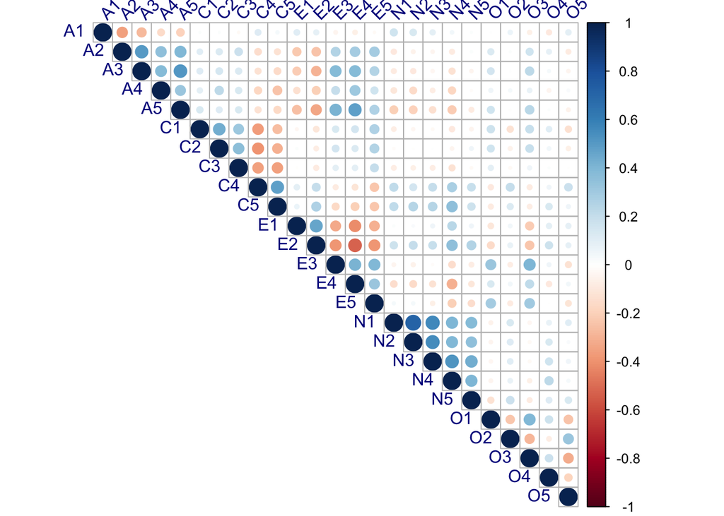

```r
mydata = bfi[1:25][complete.cases(bfi[1:25]),]
corrplot(cor(mydata), type = "upper", tl.col = "darkblue", tl.srt = 45)
```

# Factor Analysis

## R

### Checking of adequacy of factor analysis

There are some methods to check the adequacy of factor analysis. In this project, we adopt two of them as follow.

#### 1. Kaiser-Meyer-Olkin (KMO)

[Kaiser-Meyer-Olkin](https://www.statisticshowto.datasciencecentral.com/kaiser-meyer-olkin/) (KMO) is the measure of sampling adequacy, which varies between 0 and 1. The values closed to 1.0 usually means that it is useful to process the data used by factor analysis. If the value is less than 0.50, the results of the factor analysis probably won’t be very useful.

```r
KMO(mydata)
```

```
## Kaiser-Meyer-Olkin factor adequacy
## Call: KMO(r = mydata)
## Overall MSA =  0.85
## MSA for each item =
##   A1   A2   A3   A4   A5   C1   C2   C3   C4   C5   E1   E2   E3   E4   E5
## 0.75 0.84 0.87 0.88 0.90 0.84 0.80 0.85 0.83 0.86 0.84 0.88 0.90 0.88 0.89
##   N1   N2   N3   N4   N5   O1   O2   O3   O4   O5
## 0.78 0.78 0.86 0.89 0.86 0.86 0.78 0.84 0.77 0.76
```

Based on the results of KMO above, we observe the MSA for each item is greater than 0.74 and the overall MSA is 0.85, which illustrates it is useful if we use factor analysis on the data.

#### 2. Bartlett’s Test of Sphericity

[Bartlett’s Test of Sphericity](http://shodhganga.inflibnet.ac.in/bitstream/10603/9094/10/10_chapter%208.pdf) is the test for null hypothesis that the correlation matrix has an identity matrix. The significant p-value indicates null hypothesis that all off-diagonal correlations are zero is falsified.

```r
cortest.bartlett(mydata)
```

```
## $chisq
## [1] 18146.07
##
## $p.value
## [1] 0
##
## $df
## [1] 300
```

As we can see, the p-value of this test is significant, which means some of off-diagonal correlations are nonzero. It further suggests it is necessary to go ahead with factor analysis.

### Determining the Number of Factors to Extract

#### 1. Screeplot

In [screeplot](https://www.researchgate.net/publication/276934102_The_Scree_Test_and_the_Number_of_Factors_a_Dynamic_Graphics_Approach), eigenvalues of correlation matrix represent variances explained by each factor (sometimes sums of squared factor loadings are used instead). The adequate number of factors is before the sudden downward inflextion of the plot. Eigenvalues sum to the number of items, so an eigenvalue more than 1 is more informative than a single average item.

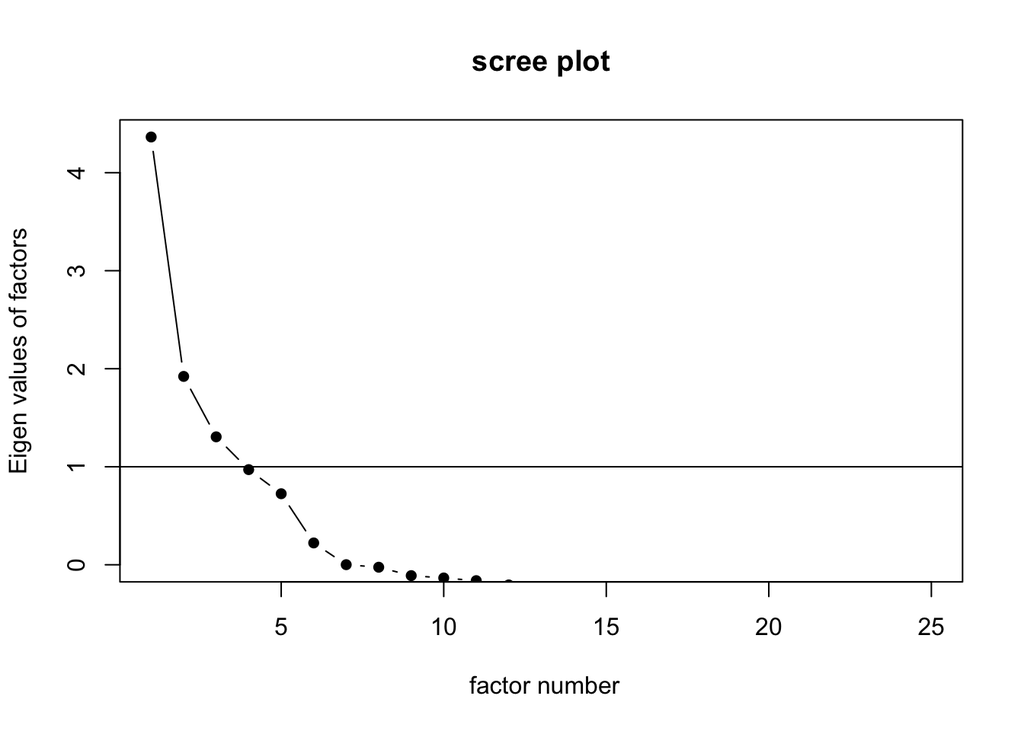

```r
scree(mydata, fa = TRUE, pc = FALSE, main = "scree plot")
```

This scree plot shows that the eigenvalues for the first three factors are all strictly greater than 1, while the fourth eigenvalue is 0.97 which is almost equal to 1. So the first four factors account for most of the total variability in data (given by the eigenvalues). The remaining factors account for a very small proportion of the variability and are likely unimportant

#### 2. Parallel analysis

[Parallel analysis](https://opensiuc.lib.siu.edu/cgi/viewcontent.cgi?referer=https://www.google.com/&httpsredir=1&article=1004&context=pb_pubs) is based on the comparison of eigenvalues of the actual data to those of the simulative data. The focal point is how many of the factors obtained from the actual data have an eigenvalue greater than that of the simulative data and accordingly the number of factors is decided. The number of factors at the point where the eigenvalue in the simulative data is greater than that of the actual data is considered significant.

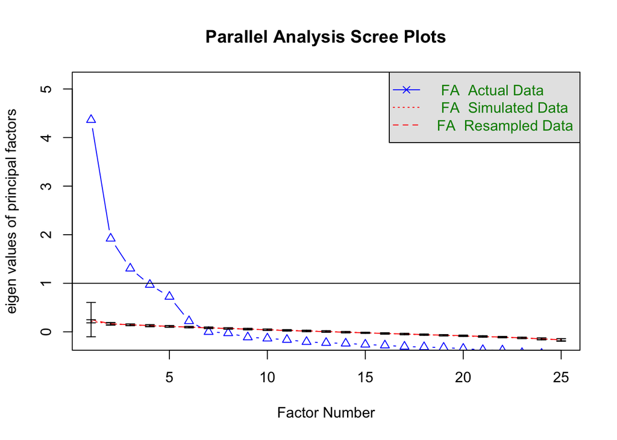

```
## Parallel analysis suggests that the number of factors =  6  and the number of components =  NA
```

```r
fa.parallel(mydata, fa = 'fa', error.bars = TRUE)
```

From Parallel Analysis scree plot, it is obvious that the six factors construct decided as a result of the examination of the eigenvalues is supported. Because the first six factors of the actual data have higher eigenvalues than the first six factors of the simulative data.

Combined results with two methods mentioned above, we should compare 4, 5 and 6 factors cases and find out which case is the most intepretable.

### Conducting Factor Analysis

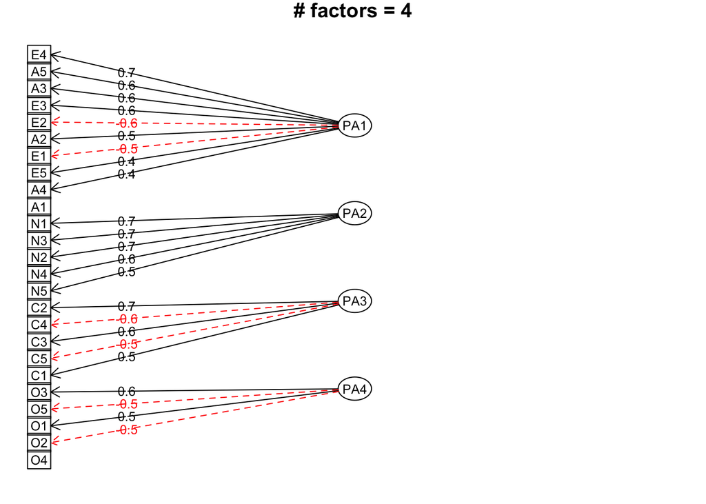

```r
fa4 = fa(mydata, nfactors = 4, fm="pa", max.iter = 100, rotate = "varimax")
fa.diagram(fa4, main = "# factors = 4")
```

As we can see, A1 and O4 do not have more dependence on each of these four factors than other items. It motivated us to try more factors.

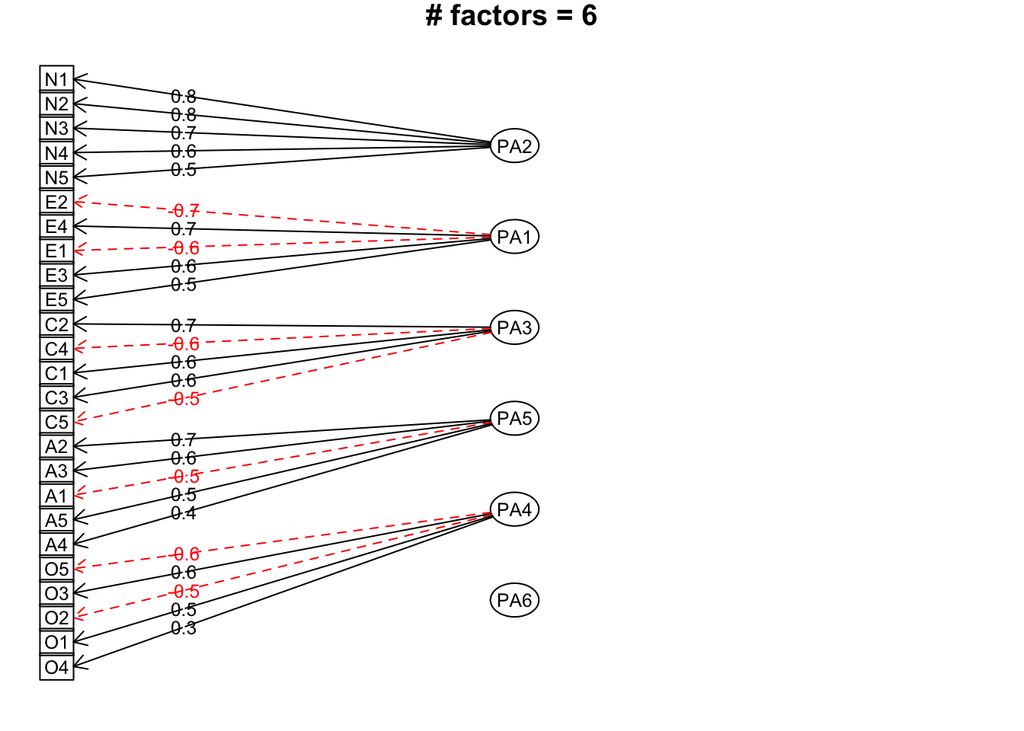

```r
fa6 = fa(mydata, nfactors = 6, fm="pa", max.iter = 100, rotate = "varimax")
fa.diagram(fa6, main = "# factors = 6")
```

Here is the factor analysis with 6 factors. No items have strong relationship with the sixth factor. Therefore, we finally try the anaylsis with 5 factors.

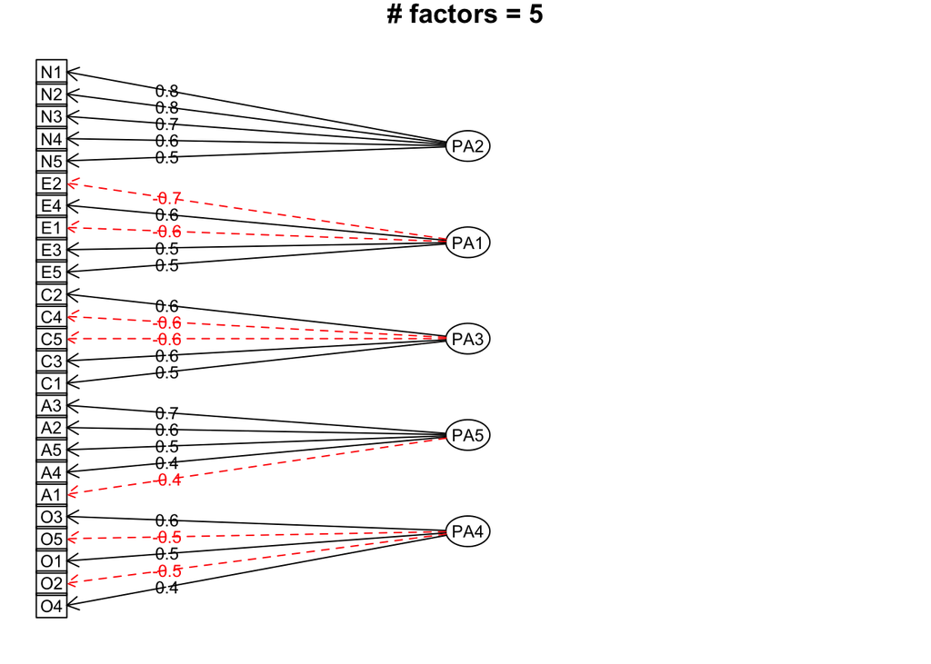

```r
fa5 = fa(mydata, nfactors = 5, fm="pa", max.iter = 100, rotate = "varimax")
fa.diagram(fa5, main = "# factors = 5")
```

With 5 factors, it is easy to see each factors corresponse to five different items, which indicates it is more interpretable.

### Detailed analysis with 5 factors

#### Factor Loadings

Below are the factor loadings with 5 factors cases. In this output, we can also see the factor loadings less than 0.1.

```r
print(fa5$loadings, cutoff=0, digits=3)
```

```
##
## Loadings:
##    PA2    PA1    PA3    PA5    PA4
## A1  0.111  0.040  0.023 -0.428 -0.078
## A2  0.030  0.214  0.139  0.627  0.062
## A3  0.009  0.318  0.109  0.651  0.056
## A4 -0.066  0.205  0.231  0.436 -0.113
## A5 -0.122  0.393  0.088  0.537  0.067
## C1  0.010  0.070  0.546  0.039  0.210
## C2  0.090  0.033  0.649  0.103  0.115
## C3 -0.031  0.024  0.557  0.112 -0.005
## C4  0.240 -0.065 -0.634 -0.038 -0.108
## C5  0.290 -0.176 -0.562 -0.048  0.037
## E1  0.043 -0.575  0.033 -0.105 -0.059
## E2  0.245 -0.679 -0.102 -0.112 -0.042
## E3  0.024  0.537  0.083  0.258  0.281
## E4 -0.116  0.647  0.102  0.306 -0.074
## E5  0.036  0.504  0.313  0.090  0.214
## N1  0.786  0.079 -0.046 -0.216 -0.085
## N2  0.754  0.027 -0.031 -0.194 -0.010
## N3  0.732 -0.061 -0.067 -0.028 -0.004
## N4  0.591 -0.345 -0.179  0.006  0.075
## N5  0.538 -0.161 -0.037  0.101 -0.150
## O1 -0.002  0.213  0.115  0.062  0.505
## O2  0.176  0.005 -0.100  0.082 -0.469
## O3  0.027  0.311  0.077  0.127  0.596
## O4  0.221 -0.191 -0.022  0.156  0.369
## O5  0.085 -0.005 -0.063 -0.010 -0.534
##
##                  PA2   PA1   PA3   PA5   PA4
## SS loadings    2.710 2.473 2.041 1.844 1.522
## Proportion Var 0.108 0.099 0.082 0.074 0.061
## Cumulative Var 0.108 0.207 0.289 0.363 0.424
```

#### Communalities

The communalities for the ith variable are computed by taking the sum of the squared loadings for that variable.
$$h_i^2 = \sum \limits_{j = 1}^m \hat{l}_{ij}^2$$
Communatities indicate the amount of variance in each variable that is accounted for.

```r
print(fa5$communality, cutoff=0, digits=3)
```

```
##    A1    A2    A3    A4    A5    C1    C2    C3    C4    C5    E1    E2
## 0.204 0.463 0.539 0.302 0.470 0.348 0.454 0.324 0.477 0.435 0.348 0.545
##    E3    E4    E5    N1    N2    N3    N4    N5    O1    O2    O3    O4
## 0.441 0.541 0.407 0.681 0.608 0.545 0.506 0.349 0.317 0.268 0.474 0.246
##    O5
## 0.296
```

Generally, communatities between 0.0-0.4 should be considered as low ones. However, almost half of the communatities below are less than 0.4. So, we should check whether the communatities go much larger as the number of factors increasing.

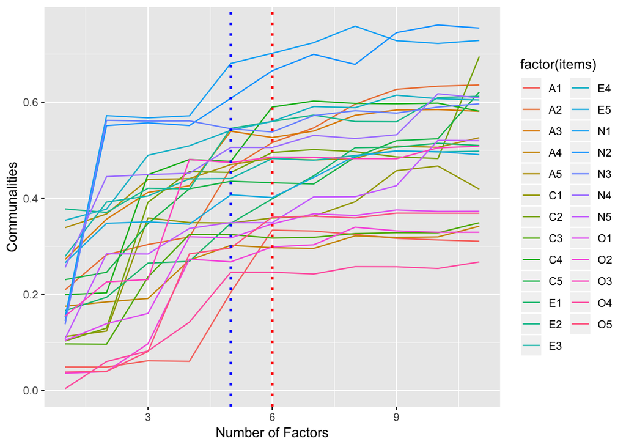

```r
com_matrix = c()
for(i in 1:11){
  result <- fa(mydata, nfactors = i, fm="pa", max.iter = 100, rotate = "varimax")
  com_matrix = rbind(com_matrix, result$communality)
}

as.tibble(com_matrix) %>%
  gather(items, loadings) %>%
  group_by(items) %>%
  mutate(n = 1:11) %>%
  ggplot(aes(x = n ,y = loadings)) +
  geom_line(aes(colour = factor(items)), size = 0.5) +
  geom_vline(xintercept = 5, linetype="dotted", color = "blue", size=1) +
  geom_vline(xintercept = 6, linetype="dotted", color = "red", size=1) +
  xlab("Number of Factors") + ylab("Communalities")
```

As we can see, when the number of factors is larger than 5 or 6, there are no obvious increases in communatities. It further illustrates 5 factors are necessary for this analysis.

#### Percentage of Variance Accounted For

We can use the eigenvalues to calculate the percentage of variance accounted for by each of the factors.

```r
nfactors = 5
fa5 = fa(mydata, nfactors = nfactors, fm="pa", max.iter = 100, rotate = "varimax")
var_per = 100*fa5$values[1:nfactors]/sum(fa5$values[1:nfactors])
cum_var = cumsum(var_per)
tb = as.data.frame(cbind(Var = var_per, Cum.var = cum_var))
tb %>%
  transmute(Factor = paste0('factor',1:nfactors),
            Var = sprintf('%4.2f%%', Var),
            Cum.var = sprintf('%4.2f%%', Cum.var)) %>%
  knitr::kable()
```

| Factor | Var | Cum.var |
| --- | --- | --- |
| factor1 | 43.43% | 43.43% |
| factor2 | 21.42% | 64.85% |
| factor3 | 14.62% | 79.47% |
| factor4 | 11.50% | 90.98% |
| factor5 | 9.02% | 100.00% |

#### Factor.plot

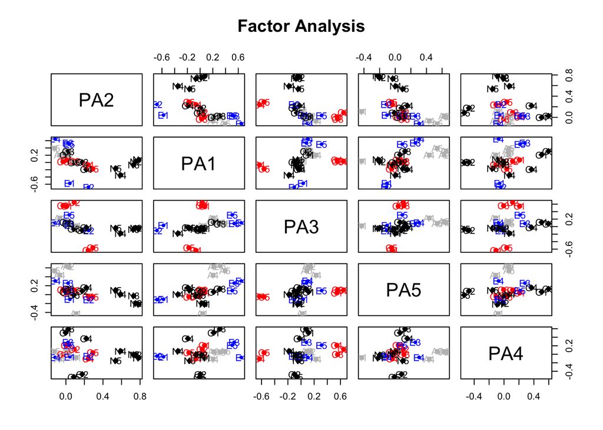

```r
factor.plot(fa5, labels = rownames(fa5$loadings))
```

### Conclusions of Factor Analysis

The Factor Analysis has thus identified 5 putative factors that affect 25 self-report personality itemss. They can be categorized as follow:

[output not shown]